# 52414 - lab 2

Yoray Mauda 315874404 and Halit Cohen 318356854

09/06/2022

### Question 1

In this question, we will wrangle and scrape data from the book “Moby Dick”, extract information, print text, make numerous manipulation on the text, and also create different distributions for it.

###### A

First, we will fetch the HTML, and then we will print the first line.

```r
# In line 35, We are creating the first paragraph, and then extract the first line out of it. In line 36 we're returning the sentence.
first_sentence <- webpage %>% html_nodes("div") %>% html_text()
first_sentence[1]
```

```
## [1] "The Project Gutenberg eBook of Moby-Dick; or The Whale, by Herman Melville"
```

##### B

```r
words_html <- webpage %>% html_text() %>% str_split(",|\\.|[:space:]")
words_html <- words_html[[1]]
words_html <- words_html[words_html!=""]
#count words
print(length(words_html))
```

```
## [1] 217192
```

```r
# length words
words_n <-nchar(words_html)
#longest word, mean, median
max(words_n)
```

```
## [1] 32
```

```r
mean(words_n)
```

```
## [1] 4.56102
```

```r
median(words_n)
```

```
## [1] 4
```

```r
# Create frequency table
freq_words <- sort(table(unlist(words_html)),
               decreasing = TRUE)
#most common word
mcw <-which.max(freq_words)
mcw
```

```
## the
##   1
```

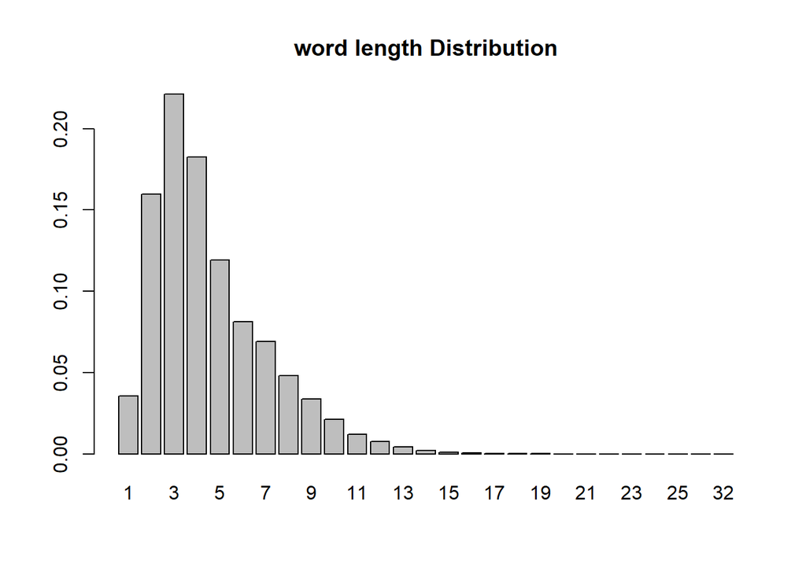

```r
# the distribution of word
tab_n<-table(str_length(words_html))/length(words_html)
barplot(tab_n,main="word length Distribution")
```

###c

```r
sort(table(words_html), decreasing = TRUE)[1:10]
```

```
## words_html
##   the    of   and    to     a    in  that   his    it     I
## 13864  6669  6067  4579  4550  3958  2831  2456  1955  1834
```

Not surprisingly, the most common words are conjunction or body pronouns.

### Question 2

###### A

In this section we will divide the text into chapters, and will plot the count of the number of words per each episode.

```r
moby_text <- html_text2(webpage)
```

To discard the beginning until the EXTRACT section, We will use `str_split` and remove the beginning.

```r
cut_text <- str_split(moby_text, "\rErromangoan.\t\r\n\r H2 anchor\r\n\r\n\n\n\n\n\r\n\r ")[[1]][2]
```

We will not print the results we have received because it is long, but we have notices that between chapters we have division that looks like `\r\n\n\r\n\n\r \r \r\n\n\r\n\r\n\n\n\n\n\r\n\r`. Thus, we will split our text based on this division.

```r
chapters <- strsplit(cut_text, "\r\n\n\r\n\n\r \r \r\n\n\r\n\r\n\n\n\n\n\r\n\r ")
chapters <- chapters[[1]]
```

Now, for plotting the data, we will loop over the chapters and extract the wanted data for our plot

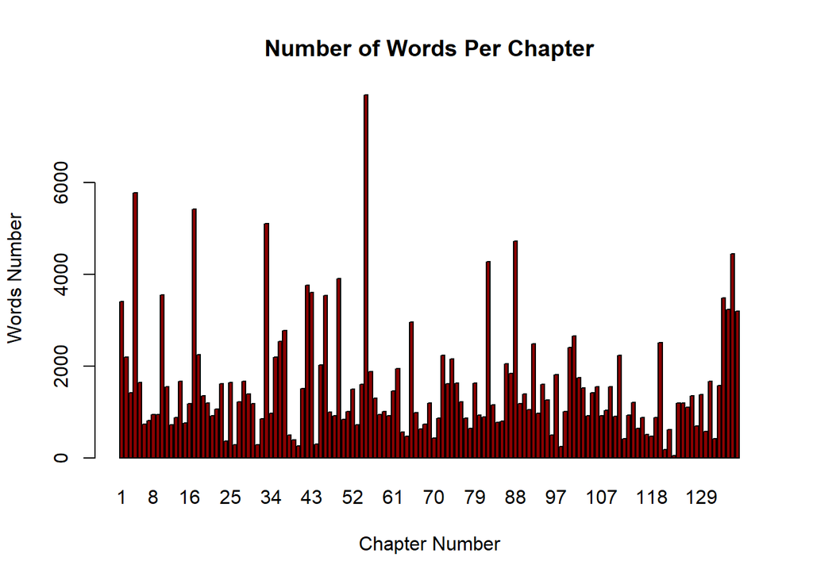

```r
  x_chapter_num <- c()
  y_words_per_chapter <- c()
  for (i in 1:length(chapters)){
    fixed_chapter_i <- str_replace_all(chapters[i], "\\s+", " ")
    splitsplat <- str_split(fixed_chapter_i, " ")
    splitsplat <- c(splitsplat)
    splitsplat <- splitsplat[[1]]
    x_chapter_num[i] <- i
    y_words_per_chapter[i] <- length(splitsplat)
  }
barplot(y_words_per_chapter, main = "Number of Words Per Chapter",
        xlab = "Chapter Number", ylab = "Words Number", names.arg = x_chapter_num,
        col = "darkred")
```

###### B

For this section we will create a function that will compute the frequency of a word in each given chapters. we will check the function and its trend in the words `Mody`, `Ahab`, and `sea`.

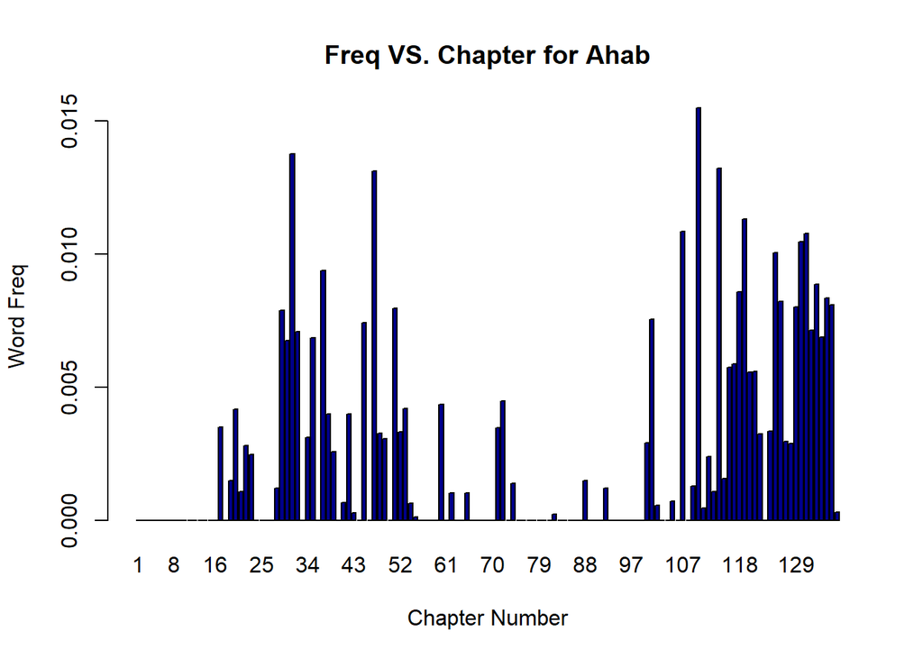

```r
Q2a <- function(word_query, chapters_num){
  relative_freq <- c()
  counter <- 1
  for (i in as.numeric(chapters_num)){
    relative_freq[counter] <- (str_count(chapters[i], word_query)/y_words_per_chapter[i])
    counter <- counter + 1
  }
return(relative_freq)
}

ahab_plot <- Q2a("Ahab", c(1:137))
barplot(ahab_plot, main = "Freq VS. Chapter for Ahab",
        xlab = "Chapter Number", ylab = "Word Freq", names.arg = x_chapter_num,
        col = "darkblue")
```

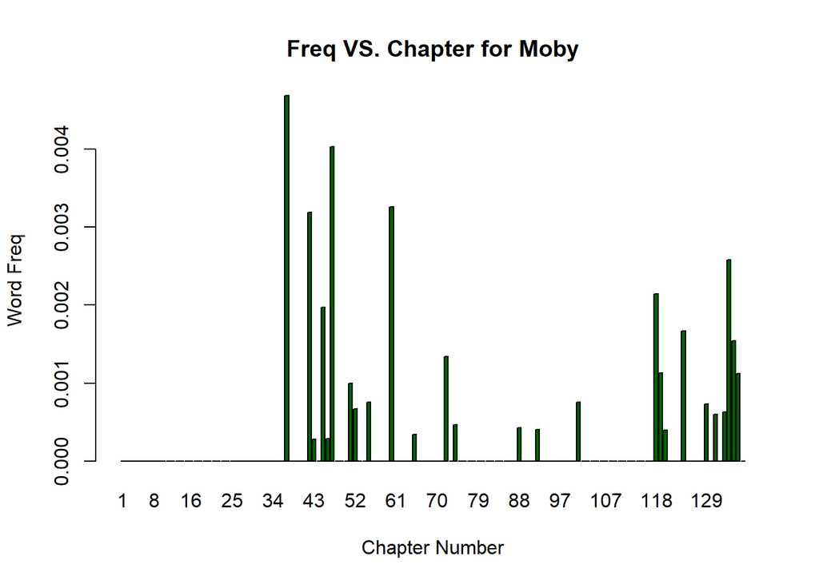

```r
moby_plot <- Q2a("Moby", c(1:137))
barplot(moby_plot, main = "Freq VS. Chapter for Moby",
        xlab = "Chapter Number", ylab = "Word Freq", names.arg = x_chapter_num,
        col = "darkgreen")
```

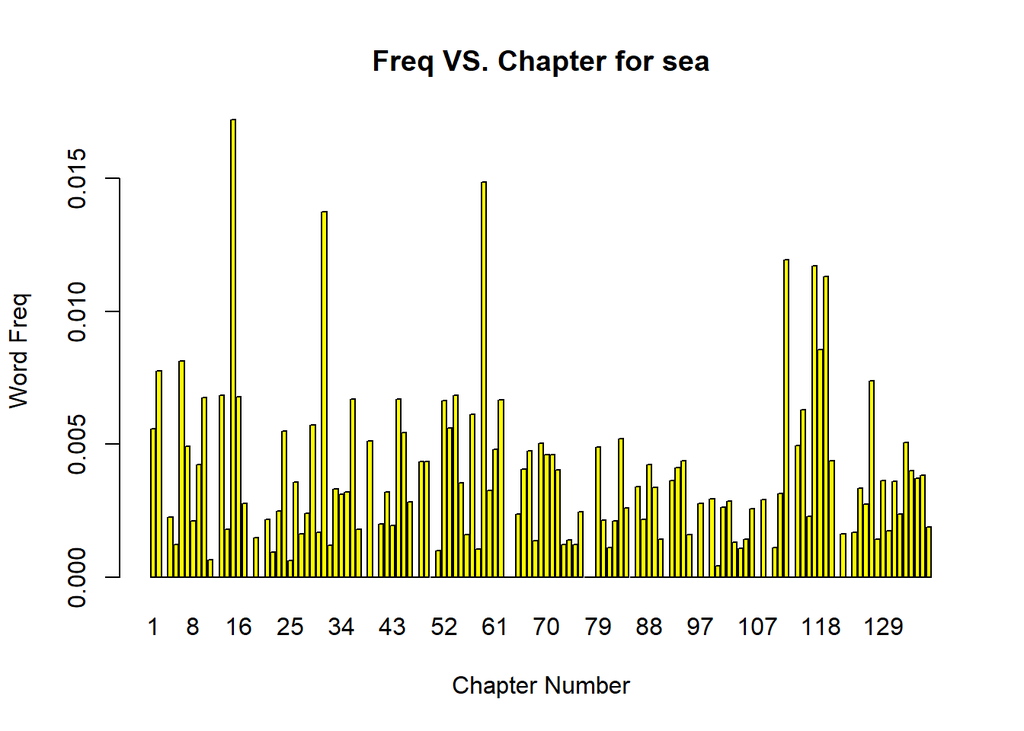

```r
sea_plot <- Q2a("sea", c(1:137))
barplot(sea_plot, main = "Freq VS. Chapter for sea",
        xlab = "Chapter Number", ylab = "Word Freq", names.arg = x_chapter_num,
        col = "yellow")
```

As we can see, the most frequent word is `sea`, which also make sense based on the book’s subject. the least frequent word is `Moby`, who barely shows in the book. For `Ahab`, we hear about him in the beginning of the book, and at the end more frequently.

###4.  
###a

```r
#clean data
clean_words <- words_html[-str_which(words_html,"[^a-z, ]+")]
clean_five_letter <-str_subset(clean_words, "^.....$")
five_letter_little<- str_to_lower(clean_five_letter)
five_letter_tab <- table(five_letter_little)
#most frequent five-letter words with their frequencies
sort(five_letter_tab, decreasing = TRUE)[1:10]
```

```
## five_letter_little
## whale which their there would other these about those great
##   640   636   613   561   414   402   376   300   296   290
```

```r
five_letter_little_2 <- five_letter_little
#The difference between all the words and 5-word words
unique_all_word <-unique(clean_words)
unique_five_words <-unique(five_letter_little)
Number_dif <- length(unique_all_word)-length(unique_five_words)
Number_dif
```

```
## [1] 13022
```

###b

```r
freq_table <- function(str) {
  #we creat matrix that help us to see the freqy prsent
  freq_mat <- matrix(0,26,5)
  colnames(freq_mat) <- c("1","2","3","4","5")
  rownames(freq_mat) <- letters[1:26]
  sum <- 1
#i -Go through every word
      #Go through each letter
  for (i in str){
    for (j in unlist(strsplit(i,""))){
       freq_mat[j,sum] <-  freq_mat[j,sum] + 1
       sum <- sum + 1
      if (sum == 6){sum <- 1}}}
  freq_mat <-freq_mat/ colSums(freq_mat)[1]
  return( freq_mat)}

freq_table_var <-freq_table(unique_five_words)
freq_table_var
```

```
##             1            2            3            4            5
## a 0.055331412 0.1608069164 0.1400576369 0.0518731988 0.0051873199
## b 0.080691643 0.0051873199 0.0138328530 0.0086455331 0.0028818444
## c 0.080691643 0.0115273775 0.0213256484 0.0518731988 0.0057636888
## d 0.040345821 0.0074927954 0.0276657061 0.0380403458 0.0893371758
## e 0.023631124 0.0968299712 0.0893371758 0.2017291066 0.1440922190
## f 0.062824207 0.0040345821 0.0092219020 0.0149855908 0.0086455331
## g 0.046685879 0.0034582133 0.0288184438 0.0305475504 0.0161383285
## h 0.042074928 0.0553314121 0.0023054755 0.0103746398 0.0461095101
## i 0.008069164 0.1100864553 0.1100864553 0.0409221902 0.0000000000
## j 0.009221902 0.0000000000 0.0005763689 0.0000000000 0.0000000000
## k 0.009221902 0.0028818444 0.0149855908 0.0484149856 0.0363112392
## l 0.046109510 0.0812680115 0.0599423631 0.0841498559 0.0414985591
## m 0.046109510 0.0115273775 0.0213256484 0.0265129683 0.0126801153
## n 0.014985591 0.0230547550 0.0680115274 0.0772334294 0.0374639769
## o 0.016138329 0.1533141210 0.1037463977 0.0351585014 0.0057636888
## p 0.063400576 0.0253602305 0.0149855908 0.0247838617 0.0121037464
## q 0.006340058 0.0017291066 0.0000000000 0.0000000000 0.0000000000
## r 0.042074928 0.1060518732 0.0824207493 0.0582132565 0.0559077810
## s 0.157348703 0.0057636888 0.0380403458 0.0628242075 0.2922190202
## t 0.066282421 0.0328530259 0.0322766571 0.0737752161 0.0939481268
## u 0.007492795 0.0657060519 0.0599423631 0.0195965418 0.0017291066
## w 0.051873199 0.0190201729 0.0121037464 0.0178674352 0.0069164265
## x 0.000000000 0.0040345821 0.0080691643 0.0005763689 0.0005763689
## y 0.006916427 0.0063400576 0.0057636888 0.0023054755 0.0847262248
## z 0.001152738 0.0005763689 0.0080691643 0.0046109510 0.0000000000
```

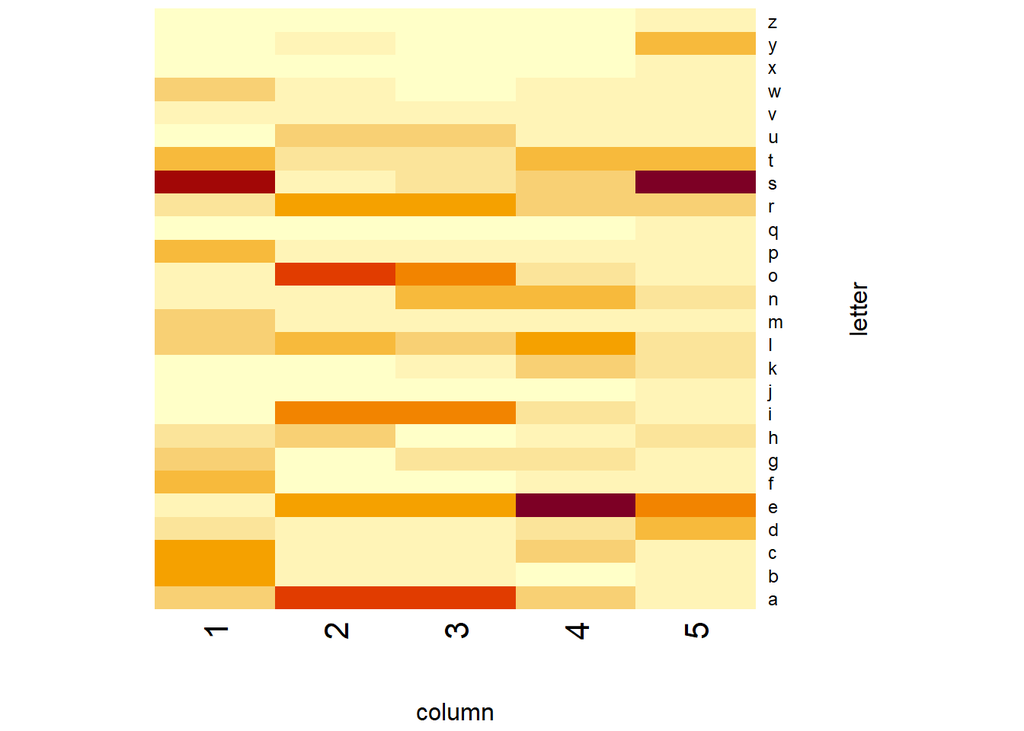

```r
#crest heatmap
heatmap(freq_table_var,Colv = NA ,Rowv = NA,scale ="column",xlab = "column",ylab = "letter")
```

###b

```r
#Here, too, we use a matrix calculation in order to show the top-10 words with the highest likelihood.
likelihood_words<- function(str) {
  tab_basis<- freq_table(str)
  #normalized to probabilities
  column_a <- as.matrix(str)
  new_word_matrix <- rep(1,length(str))
  new_word_matrix <- cbind(column_a ,new_word_matrix)
  #Create the subject of the columns
  colnames(new_word_matrix) <- c("word", "prob")
  rownames(new_word_matrix) <- c(1:length(str))
  new_word_matrix <- as.data.frame(new_word_matrix)
  new_word_matrix[,2] <- as.numeric(new_word_matrix[,2])
  #i -Go through every word
  for (i in 1:length(str)) {
    worde_2 <- unlist(strsplit(str[i],""))
    #Go through each letter
    for (j in 1:length(worde_2)){
        new_word_matrix[i,2] <- new_word_matrix[i,2] * tab_basis[worde_2[j],j]}}
  #Show the top-10 words with the highest likelihood
  order_words <- new_word_matrix[order(-new_word_matrix$prob),]
  return(order_words)}
tab_likelihood<-likelihood_words(unique_five_words)
head(tab_likelihood,10)
```

```
##       word         prob
## 269  soles 8.524251e-05
## 920  sires 8.416096e-05
## 723  sails 6.849575e-05
## 1518 soils 6.530419e-05
## 893  cares 6.304445e-05
## 1720 soars 5.747547e-05
## 584  cries 5.553386e-05
## 555  shoes 5.324576e-05
## 1389 seals 5.247369e-05
## 691  canes 5.202270e-05
```

###5 ###A

```r
#read list
url2 <- 'https://raw.githubusercontent.com/DataScienceHU/Lab_2_Cohen_Halit_and_Mauda_Yoray/main/sgb-words.txt'
# Read the html into r:
w_words <- read_html(url2)
w_words_5 <- w_words %>%html_text()
w_words_5 <-w_words_5%>% str_split("\n")%>%unlist()
class(w_words_5)
```

```
## [1] "character"
```

```r
# frequency table:
letter_freq_ww5 <-w_words_5 %>% str_split("") %>% # Split to a vector
  map(unique) %>%unlist() %>% #one letter per word
  table() %>% sort(decreasing = TRUE) %>%
  `/`(length(w_words_5)) %>% c()

#frequency table per position:
freq_table(w_words_5)
```

```
##              1            2            3            4           5
## a 0.0514156679 0.1615424700 0.1050894563 0.0588848359 0.030918881
## b 0.0750390829 0.0055584506 0.0222338023 0.0171964565 0.004168838
## c 0.0764286955 0.0142435296 0.0319610908 0.0364773319 0.008337676
## d 0.0540211916 0.0074691680 0.0309188814 0.0378669446 0.074865381
## e 0.0224075039 0.1146430433 0.0689595275 0.2133055411 0.103352441
## f 0.0552371027 0.0020844190 0.0151120375 0.0173701581 0.007642870
## g 0.0484627410 0.0041688379 0.0241445197 0.0305714782 0.010595796
## h 0.0415146778 0.0470731284 0.0067743616 0.0126802154 0.033350703
## i 0.0128539170 0.1169011638 0.0896300156 0.0493312489 0.007816571
## j 0.0126802154 0.0006948063 0.0013896126 0.0006948063 0.000000000
## k 0.0158068438 0.0050373458 0.0156331423 0.0422094841 0.024839326
## l 0.0470731284 0.0625325690 0.0673962133 0.0634010769 0.035087719
## m 0.0517630710 0.0123328122 0.0363036304 0.0326558972 0.013375022
## n 0.0204967865 0.0291818656 0.0712176481 0.0670488101 0.035261421
## o 0.0187597707 0.1582421400 0.0840715651 0.0455098141 0.026055237
## p 0.0670488101 0.0196282786 0.0293555671 0.0340455098 0.015806844
## q 0.0067743616 0.0017370158 0.0006948063 0.0000000000 0.000000000
## r 0.0465520236 0.0792079208 0.0825082508 0.0538474900 0.069654334
## s 0.1257599444 0.0069480632 0.0430779920 0.0446413062 0.306409588
## t 0.0653117943 0.0211915928 0.0486364426 0.0776446066 0.062532569
## u 0.0130276186 0.0927566441 0.0543685948 0.0267500434 0.002258121
## w 0.0396039604 0.0140698280 0.0170227549 0.0121591106 0.004863644
## x 0.0006948063 0.0057321522 0.0116380059 0.0008685079 0.005211047
## y 0.0081639743 0.0112906027 0.0118117075 0.0071217648 0.115511551
## z 0.0041688379 0.0010422095 0.0090324822 0.0071217648 0.002084419
```

```r
length(w_words_5)
```

```
## [1] 5758
```

```r
length(unique_five_words)
```

```
## [1] 1735
```

###b

```r
# Helper function:
wordle_match <- function(guess, word)  # 1: correct location, -1: wrong location, 0: missing
{
  L <- nchar(guess)
  match <- rep(0, L)
  for(i in 1:L)
  {
    if(grepl(substr(guess, i, i), word, fixed=TRUE))
      {match[i] = -1}
    if(substr(guess, i, i) == substr(word, i, i))
    {      match[i] = 1}
  }

  return(match)
}
```

```r
mach_word<- function(guess,results,dictionary){
  words_d <- dictionary
  #i -Go through every word
  #j -Go through every Single result
  for (i in dictionary){
    for (j in 1:length(results)){
      match <- wordle_match(guess[[j]], i)
      word_match_test <-match == results[[j]]
      #We will leave only what had a match
      if (length(word_match_test[word_match_test == TRUE]) != 5) {
        words_d <- words_d[words_d != i]}}}
  return(words_d)}
#chek the function
gues<- list("south", "north")
res <- list(c(-1, 1, 1, 0, 0), c(0, 1, 0, 0, 0))
mach_word(gues,res,w_words_5)
```

```
##  [1] "mouse" "lousy" "louse" "fouls" "douse" "louis" "coups" "mousy" "poufs"
## [10] "youse"
```